# 007 — Power analysis: how many more GT proteins would we need?

Author

Dan MacLean

Published

April 24, 2026

## Summary

In notebook 004 we joined Contreras *et al.*’s AlphaFold-3 oligomer predictions to a small set of plant NLRs whose true activated oligomeric state is known from experiment, giving 12 rows of “AF3 prediction + correct answer”. In 005 we asked the obvious follow-on: do the canonical SNI structural features tell apart the rows where AF3 got the oligomer right (TP) from the rows where it got it wrong (FP)? They didn’t — a standard ranger classifier did no better than always guessing the majority class. In 006 we checked whether 005’s apparent signal was at least transferring between proteins by training on three proteins and testing on the fourth; it wasn’t, and the classifier collapsed to a baseline majority-class prediction on every fold.

Our conclusion is that the classification didn’t work when we have just a few ‘real’ proteins to use. How much more data would it take before it could?

## Goal

In this document we’ll examine features - different SNI values.

- **§1 — How big does each feature’s signal look in the current data, and how sure are we?** The signal size is measured the same way as in notebook 005 (rank-AUC), and the uncertainty is shown as a bootstrap 95% CI so we don’t pretend the point estimates are exact.
- **§2 — How many rows would a standard test need to detect a signal that big?** A textbook formula (Noether 1987) converts effect size + class ratio into “minimum sample size for 80% power.” We compute it for every feature.
- **§3 — The same calculation as a curve.** Power vs sample size for the top three features, with the current `n = 12` and the 80% power target both drawn on the plot, so the gap between where we are and where we’d want to be is visible at a glance.
- **§4 — From rows to proteins.** A sample-size in rows is one unit; the more useful unit for future work is “how many new ground-truth proteins do we need to find?”. This section does that conversion.
- **§5 — Plain-language conclusion.**
- **§6 — What we’ll do next.**

### Some terms

- **AUC** (here, `auc_abs`) — Area Under the ROC Curve, a number between 0.5 and 1.0 that says how well a feature’s values separate two classes when used as a 1-D ranker. **0.5** means “no better than a coin flip — TP and FP rows are interleaved”; **1.0** means “every TP value is above every FP value (or vice versa)”. `auc_abs = max(AUC, 1 − AUC)` so the number is direction-free.
- **Power** — the probability that, if the feature really does separate the classes by the amount we observed, a standard test on a fresh sample of size `n` would correctly detect it. The conventional target is 80%: “in 4 out of 5 datasets of this size, the test would catch the signal.”
- **α** — the false-positive rate of the test. α = 0.05 is the conventional threshold: “we’ll only call a result significant if it would happen by chance in fewer than 1 in 20 datasets when there is actually no real signal.”
- **Bootstrap 95% CI** — because we only have 12 rows, the AUC point estimate is itself uncertain. The bootstrap re-samples the 12 rows with replacement many times, recomputes the AUC each time, and reports the 2.5%–97.5% range as a 95% confidence interval. A wide CI means “the true AUC could be quite different from the point estimate; the data we have can’t pin it down.”

## Hypotheses

Stated upfront so the reader can check whether what comes out of the analysis matches what we expected going in.

1. **The bootstrap CIs on per-feature AUC will be wide,** wide enough that for most features the CI overlaps AUC = 0.5 (no real signal). This is the concrete version of “12 rows, imbalanced 3:9, can’t precisely pin down an effect size.”
2. **`SD_THETA_ROT` will look strong on the point estimate** (≈ 0.96 in 005), so the sample-size formula will say we already have enough rows. But its CI will be wide, and we already know from notebook 006 that this feature’s signal doesn’t transfer across proteins — so the headline number for this feature is a misleading one to act on.
3. **The middle-ranked features** (`ipTM_LCB`, `S_PROTO`, `BSA_INT_PROTO`, `D_APEX`, AUC ≈ 0.67–0.76) will need on the order of **tens of independent proteins** for 80% power.
4. **The weakest features** (AUC ≈ 0.55) will need **hundreds to thousands** of proteins, which isn’t a realistic target for any plant-NLR curation effort.

We deliberately don’t run a multivariate classifier power analysis here. At `n = 12` the per-class feature distributions are themselves too poorly estimated for a simulation to be meaningful; any classifier-power numbers it produced would just be reading back the assumptions we’d had to invent. The univariate Wilcoxon power analysis is the defensible lower bar: if even a single-feature test needs 50+ proteins, a multivariate classifier on the same features won’t beat it on fewer.

## Setup

Same load, same dedup rule, same canonical 10 features as 005 and 006.

```r
suppressPackageStartupMessages({
  library(here)
  library(dplyr)
  library(tidyr)
  library(ggplot2)
  library(knitr)
  library(WMWssp)
})

knitr::opts_chunk$set(fig.path = "../results/figures/007_")

fm <- read.csv(here("results", "004_full_run", "feature_matrix.csv"),
               stringsAsFactors = FALSE, na.strings = c("", "NA"))
fm$is_triple_deposit <- fm$is_triple_deposit == "True"
fm$call_correct      <- ifelse(fm$call_correct == "True", TRUE,
                        ifelse(fm$call_correct == "False", FALSE, NA))

fm_dedup <- fm |>
  filter(!(archive %in% c("AF_benchmark", "Benchmarks") &
           protein == "nbnrc2a" & predicted_oligomer == 6))

gt <- fm_dedup |>
  filter(!is.na(gt_oligomer)) |>
  mutate(class = factor(ifelse(call_correct, "TP", "FP"),
                        levels = c("FP", "TP")))

CANONICAL_10 <- c("ipTM_LCB", "Sum_CONTACTS", "BSA_INT_PROTO",
                  "SD_THETA_ROT", "S_PROTO", "D_APEX",
                  "THETA_APEX_mean", "L_APEX_mean", "H_ABS_mean",
                  "MU_H_mean")
```

## 1. How big is each feature’s signal how variable is it?

The signal size is the rank-AUC of the feature (SNI value) treated as a single-feature classifier of TP vs FP, exactly as in notebook 005 §3. The uncertainty around each estimate is the bootstrap 95% CI described in the jargon section. The plot at the end is the more important artefact than the table — it’s where the reader sees that the point estimates are not as solid as they look.

```r
auc_abs <- function(x, y, pos = "TP") {
  m <- !is.na(x); x <- x[m]; y <- y[m]
  np <- sum(y == pos); nn <- sum(y != pos)
  if (np < 1 || nn < 1) return(NA_real_)
  r  <- rank(c(x[y == pos], x[y != pos]))
  U  <- sum(r[seq_len(np)]) - np * (np + 1) / 2
  a  <- U / (np * nn)
  max(a, 1 - a)
}

boot_auc_ci <- function(gt, col, n_boot = 2000, seed = 7) {
  set.seed(seed)
  out <- replicate(n_boot, {
    idx <- sample(nrow(gt), replace = TRUE)
    auc_abs(gt[[col]][idx], gt$class[idx])
  })
  c(lo = unname(quantile(out, 0.025, na.rm = TRUE)),
    hi = unname(quantile(out, 0.975, na.rm = TRUE)))
}

auc_tbl <- do.call(rbind, lapply(CANONICAL_10, function(c) {
  ci <- boot_auc_ci(gt, c)
  data.frame(feature = c,
             auc_abs = auc_abs(gt[[c]], gt$class),
             ci_lo   = ci["lo"], ci_hi = ci["hi"])
}))
auc_tbl <- auc_tbl[order(-auc_tbl$auc_abs), ]
knitr::kable(auc_tbl, digits = 3, row.names = FALSE)
```

| feature | auc_abs | ci_lo | ci_hi |
| --- | --- | --- | --- |
| SD_THETA_ROT | 0.963 | 0.800 | 1.00 |
| ipTM_LCB | 0.759 | 0.519 | 1.00 |
| S_PROTO | 0.741 | 0.514 | 1.00 |
| BSA_INT_PROTO | 0.704 | 0.500 | 1.00 |
| D_APEX | 0.667 | 0.500 | 1.00 |
| Sum_CONTACTS | 0.630 | 0.500 | 1.00 |
| MU_H_mean | 0.630 | 0.500 | 0.95 |
| L_APEX_mean | 0.556 | 0.500 | 1.00 |
| H_ABS_mean | 0.556 | 0.500 | 1.00 |
| THETA_APEX_mean | 0.519 | 0.500 | 1.00 |

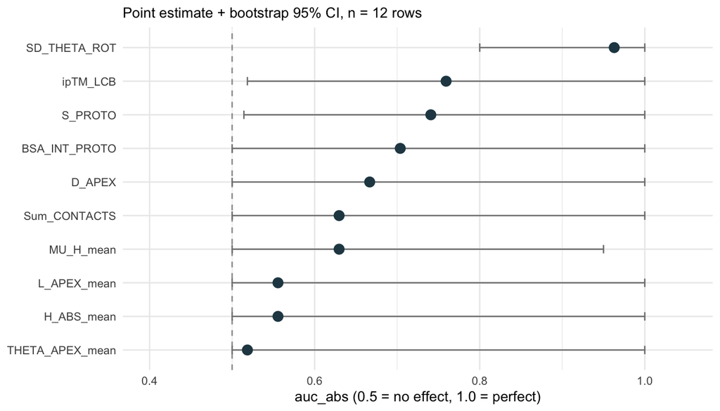

```r
ggplot(auc_tbl, aes(x = auc_abs, y = reorder(feature, auc_abs))) +
  geom_vline(xintercept = 0.5, linetype = "dashed", colour = "grey60") +
  geom_errorbarh(aes(xmin = ci_lo, xmax = ci_hi), height = 0.25,
                 colour = "grey50") +
  geom_point(size = 3, colour = "#264653") +
  labs(x = "auc_abs (0.5 = no effect, 1.0 = perfect)",
       y = NULL,
       subtitle = "Point estimate + bootstrap 95% CI, n = 12 rows") +
  xlim(0.4, 1.05) +
  theme_minimal(base_size = 10)
```

The dot is the AUC we measured on the 12 rows of SNI data the horizontal grey bar is the 95% CI from bootstrapping. The vertical dashed line at 0.5 marks “no effect.” A feature whose CI crosses or touches the 0.5 line is one where, given how little data we have, the data themselves can’t rule out “this feature has no real signal.”

What we see. The point-estimate ranking is the same as in 005’s table — `SD_THETA_ROT` at the top, the α1 features at the bottom. What’s new here is that almost every feature’s CI touches or crosses 0.5. Only `SD_THETA_ROT`’s CI clearly excludes 0.5, and even its CI runs all the way up to 1.0. The take-away from §1 is the honest one: **every sample-size number we compute in §2 is conditional on the point estimate being correct, and the point estimates are uncertain.**

## 2. How many rows would a test need to detect a signal that size?

This is where the power analysis happens. The Noether (1987) formula converts an effect size into a sample-size requirement for the Wilcoxon rank test:

$$n_{\text{total}} = \frac{(z_{\alpha/2} + z_\beta)^2}{c\,(1-c)\cdot 12\cdot (p - 0.5)^2}$$

where `p` is the AUC, `c` is the fraction of rows in the positive class, `z_{α/2} = 1.96` for α = 0.05 (two-sided), and `z_β = 0.84` for 80% power. We don’t roll our own implementation — we use the `WMWssp` package’s `WMWssp_noether()`, which is a direct implementation of this formula.

The intuition is the bit worth carrying away from the algebra. The key part is `(p − 0.5)²` in the denominator: **bigger gap from chance → fewer samples needed; smaller gap → quadratically more samples**. Halving the AUC gap (e.g. going from AUC 0.80 to AUC 0.65 — same 0.15 distance from 0.5 either side) quadruples the required sample size. That’s the reason a feature with a weak-but-real signal can need a hundred times more data than a feature with a strong signal.

The class-ratio piece, `c(1 − c)`, is maximised at `c = 0.5` (balanced) and gets worse as the classes become unbalanced. That’s why the table below shows two columns: the balanced-ideal case (1:1) and the unbalanced case we’d actually face if we kept the current 1 TP : 3 FP ratio.

```r
ssp_n <- function(auc, c_ratio, alpha = 0.05, power = 0.80) {
  WMWssp_noether(alpha = alpha, power = power,
                 t = c_ratio, p = auc)$N
}

n_tbl <- auc_tbl |>
  rowwise() |>
  mutate(n_total_1to1 = ssp_n(auc_abs, 0.5),
         n_total_1to3 = ssp_n(auc_abs, 0.25)) |>
  ungroup()
knitr::kable(
  n_tbl[, c("feature", "auc_abs", "n_total_1to1", "n_total_1to3")],
  digits = 3, row.names = FALSE,
  col.names = c("feature", "auc_abs",
                "n_total (1:1 balanced)",
                "n_total (1:3 TP:FP)"))
```

| feature | auc_abs | n_total (1:1 balanced) | n_total (1:3 TP:FP) |
| --- | --- | --- | --- |
| SD_THETA_ROT | 0.963 | 14 | 18 |
| ipTM_LCB | 0.759 | 40 | 52 |
| S_PROTO | 0.741 | 46 | 62 |
| BSA_INT_PROTO | 0.704 | 64 | 86 |
| D_APEX | 0.667 | 96 | 127 |
| Sum_CONTACTS | 0.630 | 156 | 208 |
| MU_H_mean | 0.630 | 156 | 208 |
| L_APEX_mean | 0.556 | 848 | 1131 |
| H_ABS_mean | 0.556 | 848 | 1131 |
| THETA_APEX_mean | 0.519 | 7630 | 10174 |

The features split cleanly into three bands at the observed point estimates.

- **Already within reach.** `SD_THETA_ROT` (AUC ≈ 0.96) needs only ~14–18 rows; we already have 12. The asterisk is enormous, though: as §1 showed, the CI on this AUC is wide, and as 006 showed, the apparent signal is dominated by the NbNRC2a stoichiometry sweep and doesn’t generalise across proteins. The formula’s verdict on this feature is right arithmetically but the wrong thing to act on biologically.
- **Tens of proteins away.** `ipTM_LCB`, `S_PROTO`, `BSA_INT_PROTO`, `D_APEX` (AUC ≈ 0.67–0.76) need ~40–130 total rows, depending on the class ratio. Under the rough rule that each newly-curated protein contributes one informative row (see §4), this means **on the order of 40–130 more independent GT proteins**.
- **Hundreds to thousands of rows.** `Sum_CONTACTS`, `MU_H_mean`, and the three α1 features (AUC ≈ 0.52–0.63) need 200 to 10000+ rows. These are not realistically reachable by curating more plant NLRs; they will not become detectable single-feature classifiers on this task.

## 3. The same calculation as a curve

The table in §2 gives a number per feature, but a single number is hard to put into context. The plot below shows the same calculation as a curve — power as a function of total sample size — for the top three features. Two reference lines are drawn so the reading is direct: a horizontal dashed line at 80% power (the conventional target) and a vertical dashed line at our current `n = 12`.

`WMWssp_noether()` returns the sample size needed for a target power; it doesn’t return the power achievable at a given sample size. We get the curve by calling the package the way it wants to be called: sweep the target power from 0.05 to 0.999, ask the package what N that would require at each level, and plot the resulting (N, power) pairs. The package does the arithmetic.

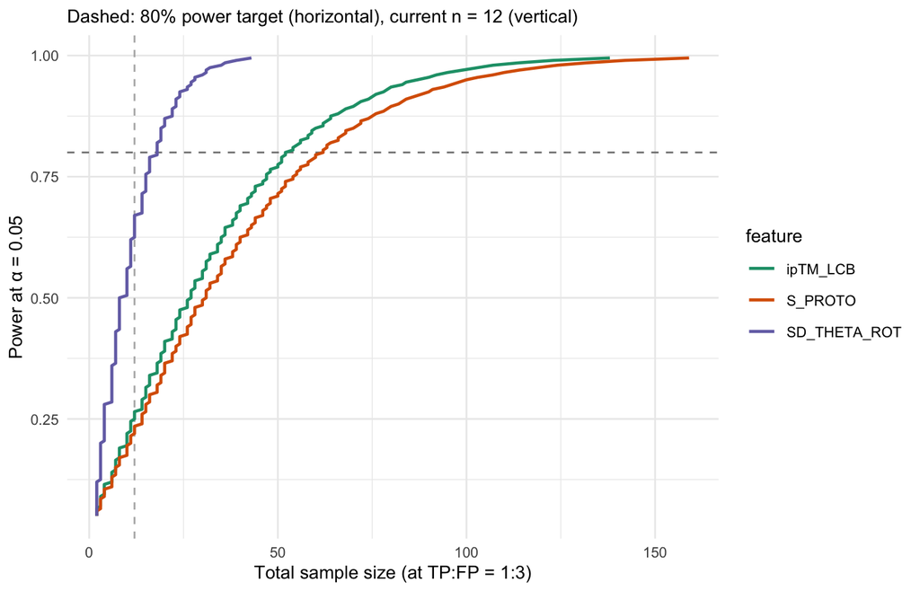

```r
top3 <- head(auc_tbl$feature, 3)
power_grid <- seq(0.05, 0.999, by = 0.005)

grid <- do.call(rbind, lapply(top3, function(f) {
  a <- auc_tbl$auc_abs[match(f, auc_tbl$feature)]
  data.frame(
    feature = f,
    auc     = a,
    power   = power_grid,
    n_total = sapply(power_grid, function(pw)
      WMWssp_noether(alpha = 0.05, power = pw,
                     t = 0.25, p = a)$N)
  )
}))
grid <- grid[grid$n_total <= 200, ]

ggplot(grid, aes(x = n_total, y = power, colour = feature)) +
  geom_hline(yintercept = 0.8, linetype = "dashed", colour = "grey50") +
  geom_vline(xintercept = 12,  linetype = "dashed", colour = "grey70") +
  geom_line(linewidth = 0.8) +
  scale_colour_brewer(palette = "Dark2") +
  labs(x = "Total sample size (at TP:FP = 1:3)", y = "Power at α = 0.05",
       subtitle = "Dashed: 80% power target (horizontal), current n = 12 (vertical)") +
  theme_minimal(base_size = 10)
```

The plot shows at what point the number of replicates gives you an 80% chance of classifying correctly. Find the feature you care about (curve colour), trace it across the x-axis until it crosses the horizontal 80% line, then read the x-value beneath the crossing. That x-value is the total sample size that feature would need for a Wilcoxon test to detect its signal in 4 out of 5 hypothetical datasets at the AUC we currently observe.

## 4. From rows to proteins: how many new ones to curate?

The numbers in §2 and §3 are in *rows*. A row count isn’t directly useful for a curation plan — what we actually need to know is “how many new proteins” — so this section translates.

If we assume independent proteins (not very close orthologues), the realistic assumption is **each new GT protein contributes about one informative row** — typically the AF3 prediction of its activated state, classified as TP or FP against the experimental result. Under that rule of thumb, the row counts in §2 convert as follows:

```r
convert_tbl <- n_tbl |>
  mutate(n_proteins_1to3 = n_total_1to3,
         n_new_proteins  = pmax(n_total_1to3 - 4, 0)) |>
  select(feature, auc_abs, n_total_1to3, n_proteins_1to3, n_new_proteins)
knitr::kable(convert_tbl, digits = 3, row.names = FALSE,
             col.names = c("feature", "auc_abs",
                           "n total rows (1:3)",
                           "≈ n proteins",
                           "≈ n new proteins on top of 4"))
```

| feature | auc_abs | n total rows (1:3) | ≈ n proteins | ≈ n new proteins on top of 4 |
| --- | --- | --- | --- | --- |
| SD_THETA_ROT | 0.963 | 18 | 18 | 14 |
| ipTM_LCB | 0.759 | 52 | 52 | 48 |
| S_PROTO | 0.741 | 62 | 62 | 58 |
| BSA_INT_PROTO | 0.704 | 86 | 86 | 82 |
| D_APEX | 0.667 | 127 | 127 | 123 |
| Sum_CONTACTS | 0.630 | 208 | 208 | 204 |
| MU_H_mean | 0.630 | 208 | 208 | 204 |
| L_APEX_mean | 0.556 | 1131 | 1131 | 1127 |
| H_ABS_mean | 0.556 | 1131 | 1131 | 1127 |
| THETA_APEX_mean | 0.519 | 10174 | 10174 | 10170 |

The right-hand column is the practically useful one: **how many plant NLRs with experimentally-resolved activated oligomeric state would we need to add to the four we already have to make each feature individually detectable** at 80% power.

## 5. Summary

** The data we have right now can’t precisely measure the effect sizes themselves.** Almost every per-feature AUC’s 95% CI touches or crosses 0.5 (no effect) — including some of the higher point estimates. So every sample-size number in §2 and §3 is conditional on the point-estimate AUC being right, and at `n = 12` the point estimates are not pinned down. Treat the numbers as “order of magnitude” guides, not as exact targets.

**For the middle band of features (`ipTM_LCB`, `S_PROTO`, `BSA_INT_PROTO`, `D_APEX`, AUC ≈ 0.67–0.76), the realistic target is roughly 40–130 independent GT proteins on top of the 4 we have.** This is a non-trivial but reachable curation programme, plausibly addressable in the near term.

**The weakest features won’t become useful single-feature classifiers no matter how much more data we collect.** When the required sample is in the hundreds to thousands of independent proteins, the answer for a structural-biology curation programme is “this feature is not really good for this task.” Of course, these numbers are not super strong, but it is suggestive that these features are not very useful in the SNI overall.